# SurvMarker

[figure not shown]

## Introduction to SurvMarker

SurvMarker is an R package designed for PCA-based weighted feature scoring method in high-dimensional molecular data, such as gene or miRNA expression matrices. The package provides a statistically principled workflow that integrates PCA with time-to-event outcomes to identify features whose variation is systematically associated with patient survival. Rather than relying on arbitrary thresholds or single-PC effects, SurvMarker aggregates survival-relevant signals across multiple PCs and calibrates feature importance using empirical null distributions.

## Dependencies

`survival`, `ggplot2`, `VennDiagram`

## PCA-based feature scoring

### Main function call

```r
pca_based_weighted_score(
  X,
  time,
  status,
  covar = NULL,
  n_pcs = 50,
  cumvar_threshold = NULL,
  max_pcs = 50,
  pc_fdr_cutoff = 0.05,
  feature_fdr_cutoff = 0.05,
  null_B = 500,
  seed = 1,
  scale_pca = TRUE,
  use_abs_loadings = TRUE,
  store_null = TRUE,
  verbose = TRUE
)
```

### Function arguments

| Argument | Description |
| --- | --- |
| `X` | Expression matrix of dimension *n_samples × p_features*. Rows correspond to samples and columns to molecular features (e.g., genes, miRNAs, proteins). |
| `time` | Survival times, ordered consistently with the rows of `X`. |
| `status` | Event indicator (1 = event, 0 = censored). |
| `covar` | Clinical covariates to include in Cox regression models. |
| `n_pcs` | Number of principal components to retain. Ignored if `cumvar_threshold` is specified. |
| `cumvar_threshold` | Minimum cumulative variance threshold used to determine the number of PCs retained. |
| `max_pcs` | Hard upper bound on the number of PCs used (safety cap). |
| `pc_fdr_cutoff` | False discovery rate cutoff for selecting survival-associated principal components. |
| `feature_fdr_cutoff` | False discovery rate cutoff for selecting prognostic molecular features. |
| `null_B` | Number of empirical null resamples used for feature-level inference. |
| `seed` | Random seed for reproducibility. |
| `scale_pca` | Logical: Whether to scale features prior to PCA. |
| `use_abs_loadings` | Logical: Whether absolute loadings are used in feature score aggregation. |
| `store_null` | Logical: Whether to store the full empirical null score matrix. |
| `verbose` | Logical: Whether to print progress messages during execution. |

### Returned values

| Component | Description |
| --- | --- |
| `feature_table` | Data frame containing feature loadings on survival-associated PCs, aggregated feature scores (*S<sub>j</sub>*), empirical p-values, and false discovery rates (FDR). |
| `pc_table` | PCA summary table including eigenvalues, proportion and cumulative variance explained, Cox regression coefficients, and adjusted p-values for each PC. |
| `pc_scores` | Sample-level principal component scores used for downstream visualization and clustering. |
| `null_scores` | Empirical null score matrix (*features × null_B*), returned when `store_null = TRUE`. |
| `selected_features` | Character vector of prognostically significant features passing feature-level FDR control. |

## Visualizations

### Example 1: Gene expression data from TCGA-LAML cohort

#### PCA diagnostics

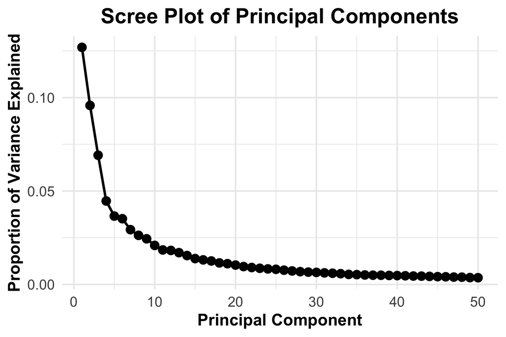

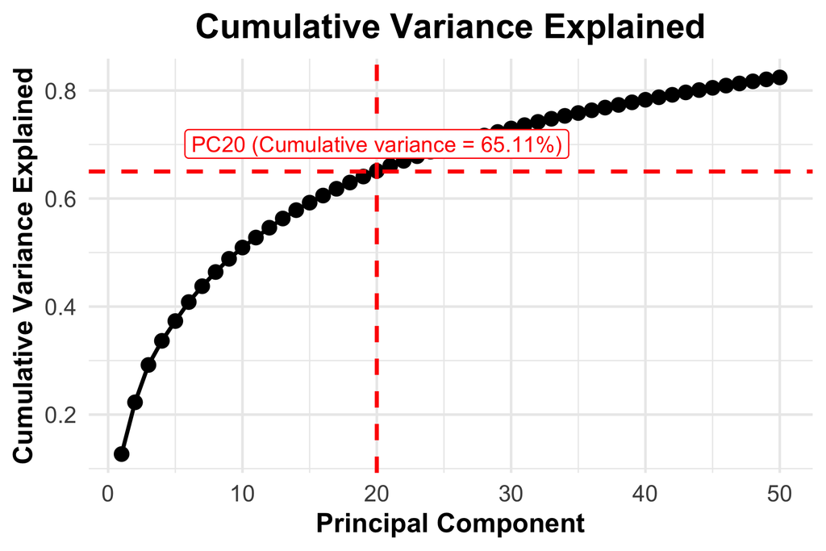

#### Survival-associated structure

`plot_pc12()` and `plot_top2_survival_pcs()` visualize survival-relevant latent structure using PC scores annotated by clinical or molecular groups.

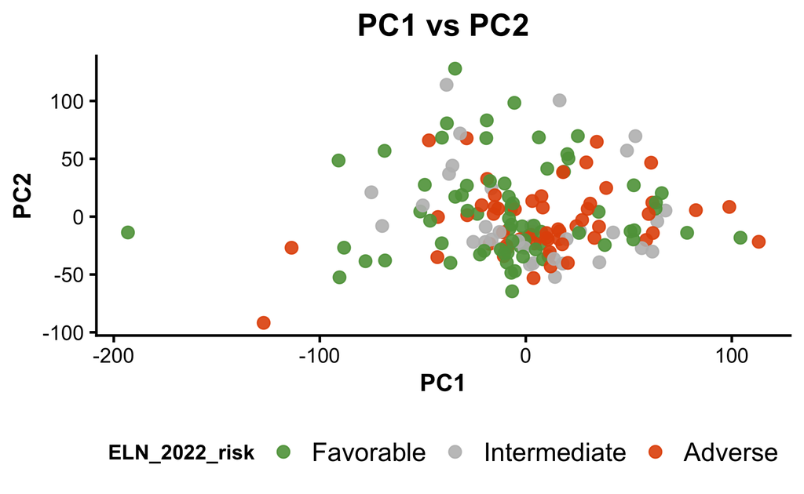

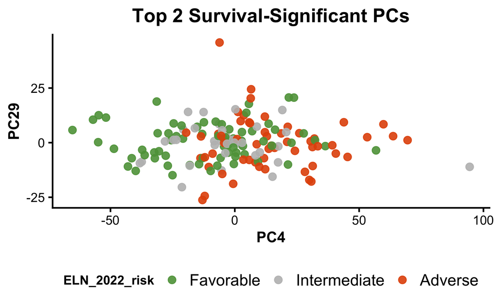

#### Feature-level inference

`plot_null_vs_observed()` contrasts observed feature scores against empirical null distributions, distinguishing significant from non-significant features.

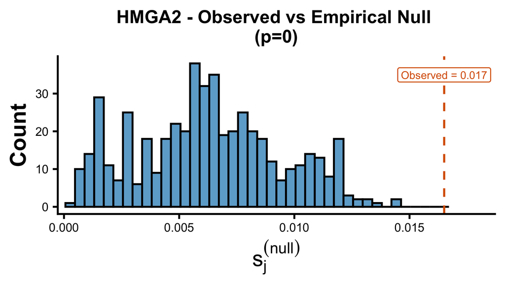

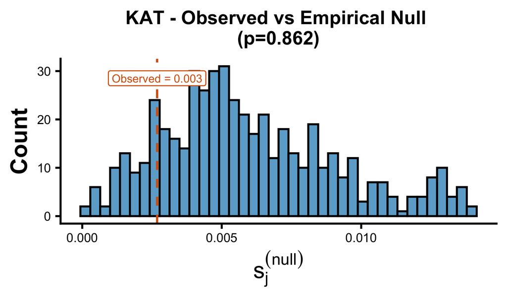

#### Sensitivity to PC choice and feature stability assessment

`plot_venn()` visualizes overlap of selected features across PC choices and `plot_feature_set_tradeoff()` summarizes the relationship between cumulative variance explained and feature set size.

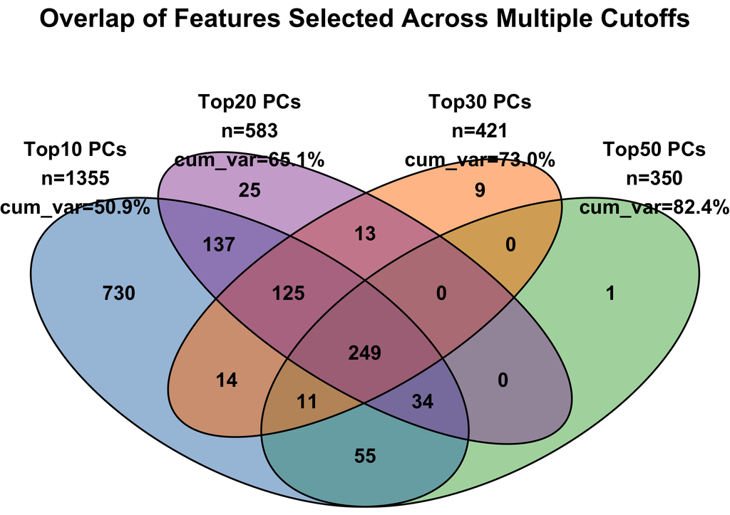

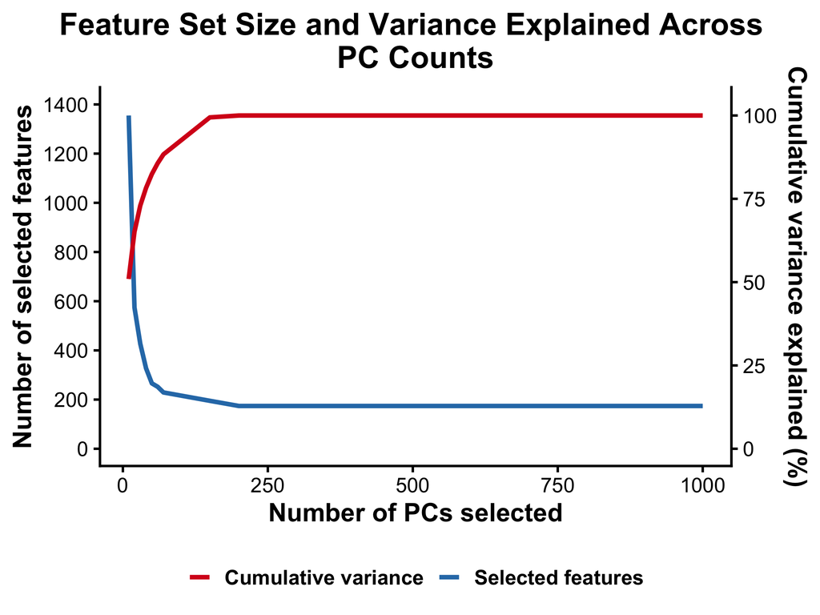

### Example 2: miRNA expression data from TCGA-LAML cohort

#### PCA diagnostics

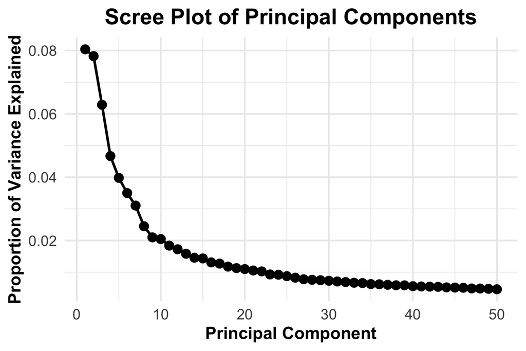

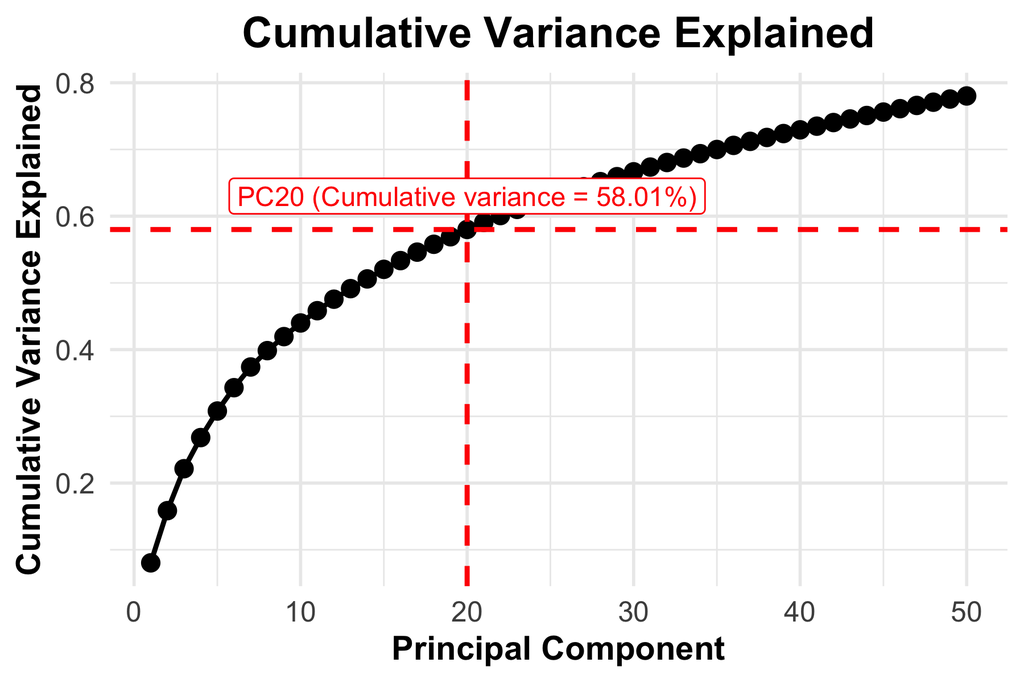

#### Survival-associated structure

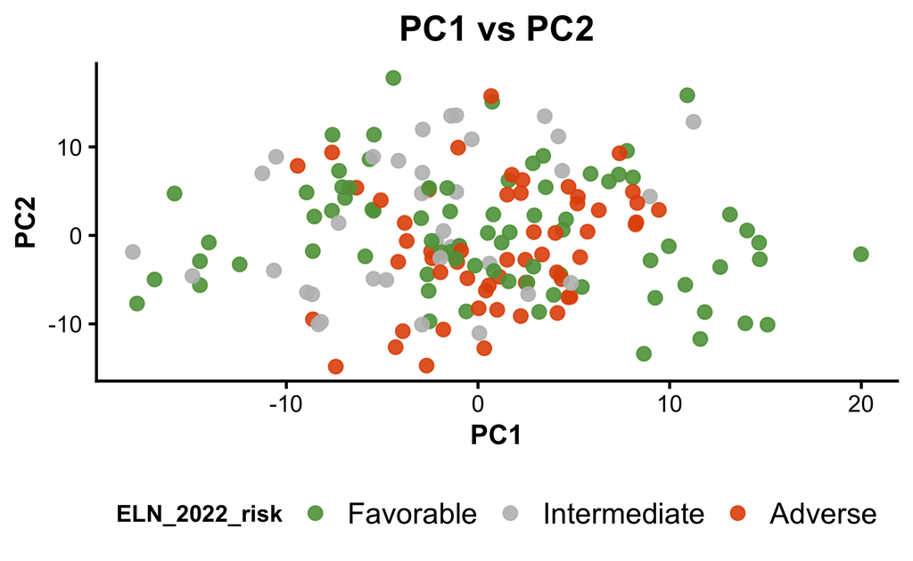

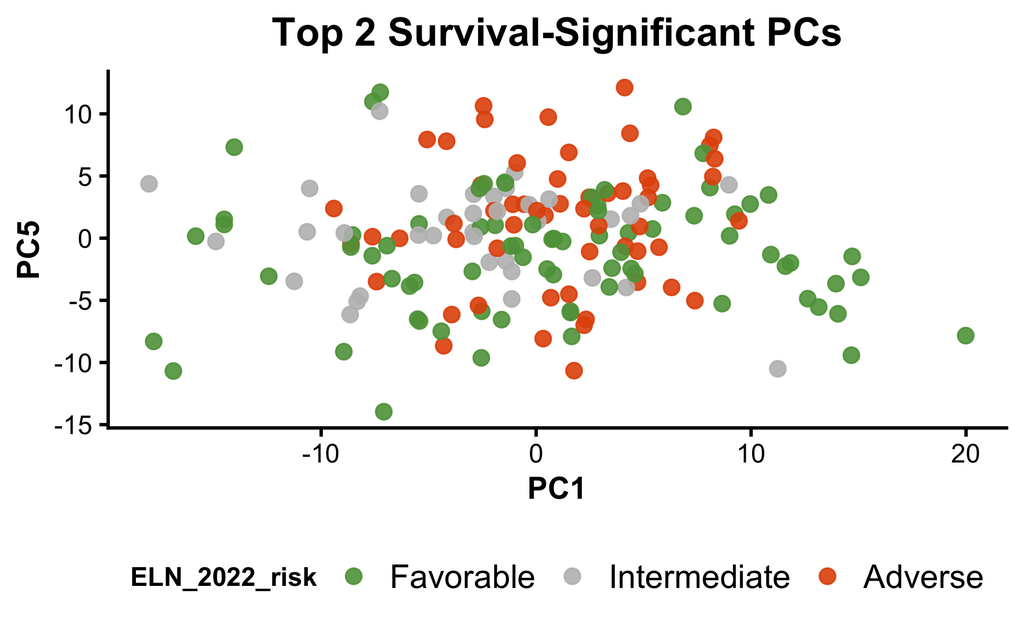

#### Feature-level inference

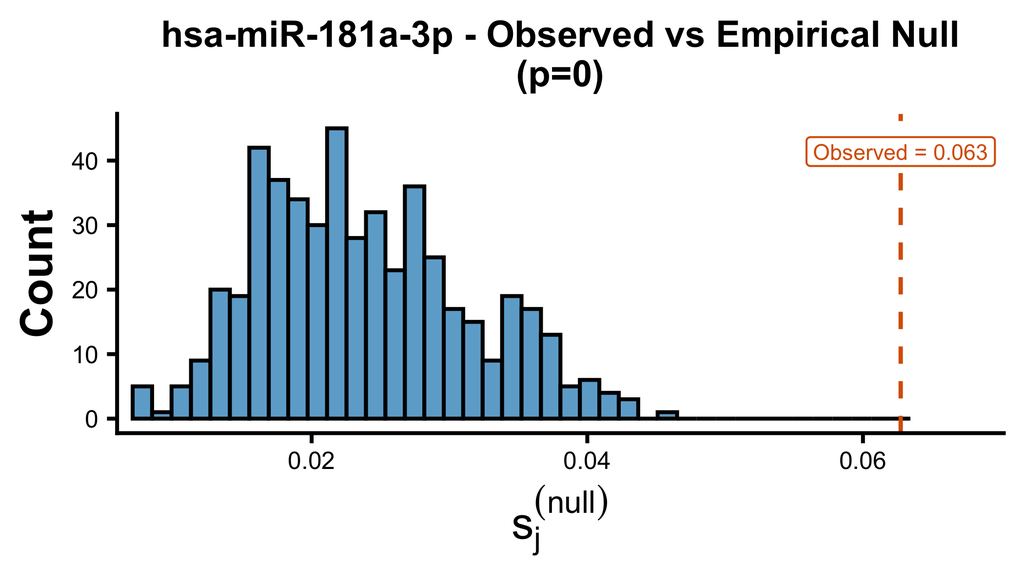

[figure not shown]

#### Sensitivity to PC choice and feature stability assessment

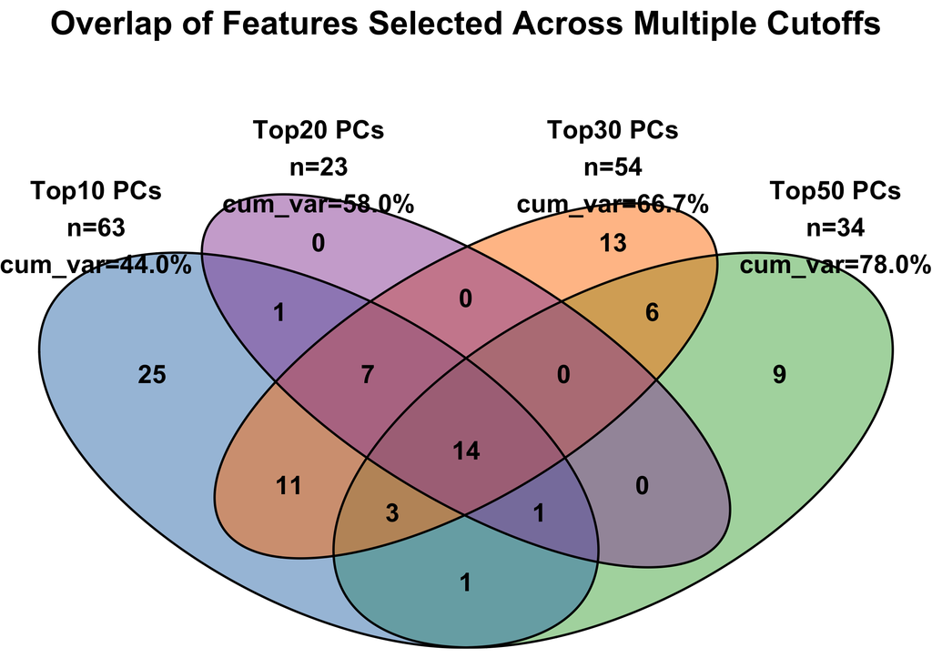

[figure not shown]

## Notes

- `SurvMarker` is designed for survival-associated biomarker discovery and builds on classical survival analysis, particularly the Cox proportional hazards model.
- Users should have basic knowledge with survival analysis concepts, particularly the input dataset.
- An `event` denotes the event of interest (e.g., death, relapse, or progression) and is represented by a survival time and an event indicator (1 = event, 0 = censored). Here `censored` represents the event of interest was not observed for a subject during the study period.
- Given a molecular feature matrix and corresponding survival time and status vectors, `SurvMarker` can be applied directly.